# SLAPNAP Report: VRC01

SLAPNAP Team

20 April, 2020

# 1 Executive summary

The NAb studied in this analysis is VRC01. The analysis considered 5 measures of sensitivity: IC-50, IC-80, IIP, estimated sensitivity, multiple sensitivity. IIP is calculated as
$$\frac{10^m}{\mbox{IC-50}^m + 10^m} ,$$
where $m = \mbox{log}_{10}(4) / (\mbox{log}_{10}(\mbox{IC-80}) - \mbox{log}_{10}(\mbox{IC-50}))$. Estimated sensitivity is defined by the binary indicator that IC-50 > 1. Since only one antibody was specified for this analysis, multiple sensitivity is the same as estimated sensitivity. Based on this specification of NAb and outcomes:

- 828 sequences were extracted from the CATNAP database;
- 476 sequences had complete data and were used in the analysis;
- out of the sequences with complete data, 111 were estimated to be resistant to the antibody, while 365 were estimated to be sensitive (using estimated sensitivity);
- out of the sequences with complete data, 111 were estimated to be resistant to the antibody, while 365 were estimated to be sensitive (using multiple sensitivity).

Prediction of each outcome was performed using a super learner ensemble of several random forests with varied tuning parameters, several gradient boosted trees with varied tuning parameters and several elastic net regressions with varied tuning parameters and intercept-only regression.

The specific algorithms used in the learning process are described in Table 1.1.

Table 1.1: Algorithms used in the super learner library

| Label | Description |
| --- | --- |
| SL.ranger.small | random forest with mtry equal to one-half times square root of number of predictors |
| SL.ranger.reg | random forest with mtry equal to square root of number of predictors |
| SL.ranger.large | random forest with mtry equal to two times square root of number of predictors |
| SL.xgboost.2 | boosted regression trees with maximum depth of 2 |
| SL.xgboost.4 | boosted regression trees with maximum depth of 4 |
| SL.xgboost.6 | boosted regression trees with maximum depth of 6 |
| SL.xgboost.8 | boosted regression trees with maximum depth of 8 |
| SL.glmnet.0 | Elastic net with lambda selected by CV and alpha equal to 0 |
| SL.glmnet.25 | Elastic net with lambda selected by 5-fold CV and alpha equal to 0.25 |
| SL.glmnet.50 | Elastic net with lambda selected by 5-fold CV and alpha equal to 0.5 |
| SL.glmnet.75 | Elastic net with lambda selected by 5-fold CV and alpha equal to 0.75 |
| SL.mean | intercept only regression |

The predictive ability of the learner was assessed using cross-validation. The estimated cross-validated $R^2$ of the super learner for predicting continuous outcomes are shown in Table 1.2. The estimated cross-validated area under the receiver operating characteristic curve (AUC) of the super learner for predicting binary sensitivity measures are shown in Table 1.3.

Table 1.2: Estimates of 5-fold cross-validated $R^2$ for super learner predictions of the continuous-valued outcome(s) (n = 476 observations with complete sequence data).

|  | CV - R^2 | Lower 95% CI | Upper 95% CI |
| --- | --- | --- | --- |
| IC-50 | 0.216 | 0.155 | 0.272 |
| IC-80 | 0.230 | 0.172 | 0.284 |
| IIP | 0.037 | 0.007 | 0.067 |

Table 1.3: Estimates of 5-fold cross-validated AUC for super learner predictions of the binary-valued outcome(s) (n = 476 observations with complete sequence data).

|  | CVAUC | Lower 95% CI | Upper 95% CI |
| --- | --- | --- | --- |
| Estimated sensitivity | 0.716 | 0.596 | 0.811 |
| Multiple sensitivity | 0.682 | 0.559 | 0.784 |

We define the marginal biological importance of a subgroup of features as the difference in population predictiveness between the best possible prediction function based on the features under consideration plus geographic confounders versus only geographic confounders. In Table 1.4, we display the groups of variables and their ranked marginal biological variable importance for predicting each outcome. The groups are displayed in order of decreasing average rank across outcomes. Stars next to ranks denote groups with p-value less than 0.05 from a hypothesis test with null hypothesis of zero importance. For variable group definitions, please refer to Table 7.1.

| Variable group | Estimated sensitivity | IC-50 | IC-80 | IIP | Multiple sensitivity |
| --- | --- | --- | --- | --- | --- |
| gp120 CD4 binding sites | 1* | 1 | 1 | 5 | 4 |
| gp120 V2 | 6 | 2 | 2 | 1 | 1 |
| Region-specific counts of PNG sites | 3 | 6 | 3 | 3 | 5 |
| gp41 MPER | 5 | 4 | 6 | 2 | 3 |
| Viral geometry | 2 | 5 | 4 | 4 | 7 |
| gp120 V3 | 4 | 7 | 5 | 7 | 2 |
| Cysteine counts | 7 | 3 | 7 | 6 | 6 |

# 2 Results for IC-50

## 2.1 Descriptive statistics

A summary of the distribution of measured IC-50 for the selected neutralizing antibody is shown in Figure 2.1.

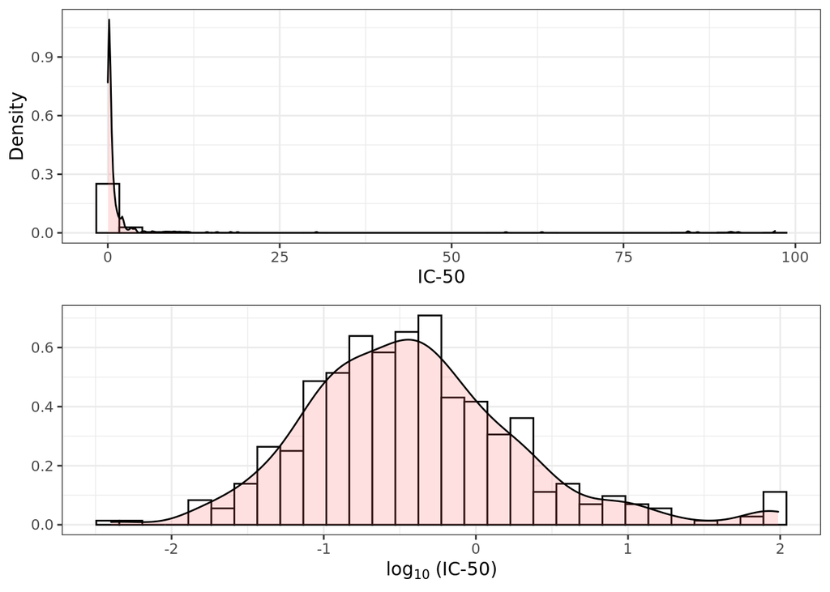

Figure 2.1: Histogram of IC-50 for the selected neutralizing antibody. Top row = original scale; bottom row = log10 scale (n = 476 observations with complete sequence data).

## 2.2 Super learner results

The weights assigned to each algorithm for Super Learner predicting IC-50 are shown in Table 2.1.

Table 2.1: Table of super learner weights for IC-50 (n = 476 observations with complete sequence data).

| Learner | Weight |
| --- | --- |
| SL.ranger.small | 0.00 |
| SL.ranger.reg | 0.44 |
| SL.ranger.large | 0.14 |
| SL.xgboost.2 | 0.18 |
| SL.xgboost.4 | 0.00 |
| SL.xgboost.6 | 0.00 |
| SL.xgboost.8 | 0.00 |
| SL.glmnet.0 | 0.05 |
| SL.glmnet.25 | 0.20 |
| SL.glmnet.50 | 0.00 |
| SL.glmnet.75 | 0.00 |
| SL.mean | 0.00 |

## 2.3 Predictive performance

The cross-validated performance, as measured by $R^2$, of the super learner and constituent algorithms (descriptions of algorithms shown in Table 1.1) in predicting IC-50 are shown in Figure 2.2.

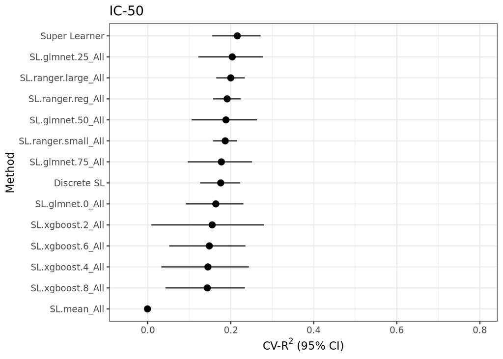

Figure 2.2: Cross-validated $R^2$ for estimated IC-50 (476 observations with complete sequence data)

Figure 2.3 shows cross-validated predictions of IC-50 plotted against observed values of IC-50, colored by cross-validation fold.

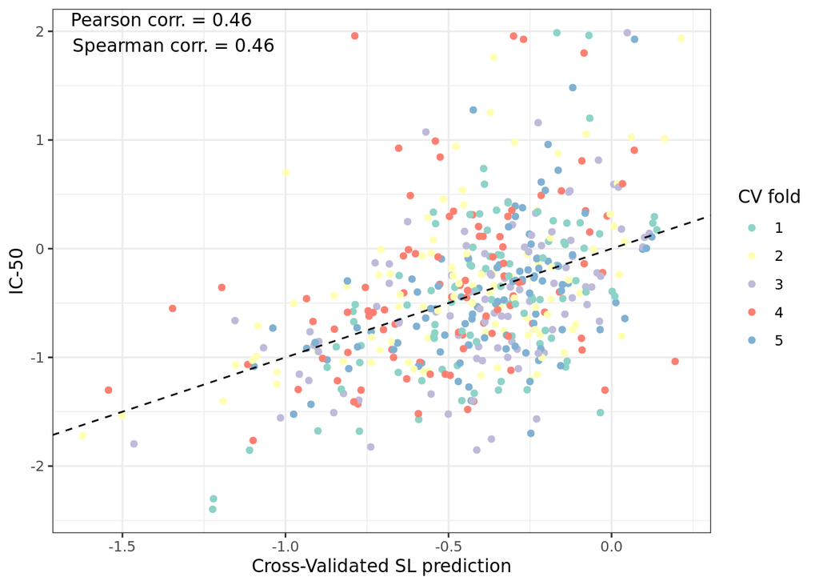

Figure 2.3: Cross-validated super learner predicted IC-50 plotted against actual IC-50 values (476 observations with complete sequence data) . Colors correspond to cross-validation folds.

## 2.4 Variable importance

### 2.4.1 Biological importance

The biological variable importance of groups of features (defined in Table 7.1) for predicting IC-50 is shown in Figure 2.4. Importance is defined using the difference in $R^2$ values. The plot shows the marginal biological importance of the group relative to the null model with geographic confounders only. 95% confidence intervals and stars denoting p-values less than 0.05 are displayed in blue.

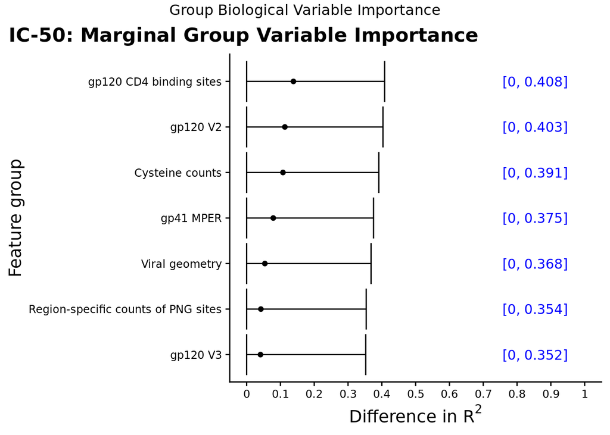

Figure 2.4: Group biological variable importance for predicting IC-50. We used the 476 observations with complete sequence data in this analysis. To estimate the prediction function based on geographic confounders only, we used 239 observations. To estimate the prediction function based on the feature group of interest plus geographic confounders, we used the remaining 237 observations.

We show the biological variable importance of individual features in predicting IC-50 in Figure 2.5. Importance is defined using the difference in $R^2$ values. The plot shows the marginal biological importance of the feature relative to the null model with geographic confounders only. 95% confidence intervals and stars denoting p-values less than 0.05 are displayed in blue.

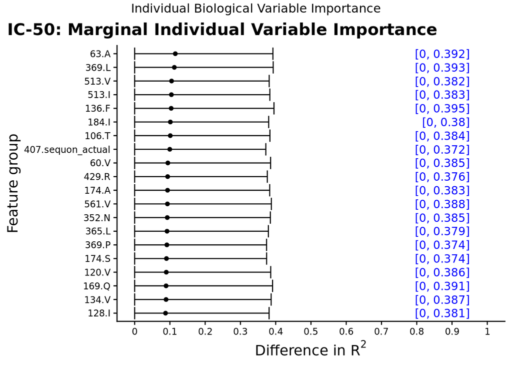

Figure 2.5: Individual biological variable importance for predicting IC-50. We used the 476 observations with complete sequence data in this analysis. To estimate the prediction function based on geographic confounders only, we used 239 observations. To estimate the prediction function based on the feature of interest plus geographic confounders, we used the remaining 237 observations.

### 2.4.2 Predictive importance

Table 2.2 shows the top 20 features. Specifically, the algorithm with the largest weight in the super learner ensemble was selected and associated variable importance metrics for this algorithm are shown. In this case, the highest weight was assigned to a rf algorithm, and thus the variable importance measures presented correspond to random forest variable permutation-based variable importance measures were computed and are shown by their rank. The permutation-based importance measures the decrease in predictive accuracy when making out-of-bag predictions and randomly permuting a given feature from its original values.

Table 2.2: The top 20 important features for predicting IC-50 as measured by their algorithm-specific importance.

| Feature | Importance |
| --- | --- |
| num.sequons.gp120 | 1.6295297 |
| num.sequons.env | 1.3218284 |
| length.gp120 | 0.9872738 |
| length.env | 0.8132571 |
| hxb2.234.sequon_actual.1mer | 0.6647415 |
| hxb2.137.gap.1mer | 0.6633978 |
| hxb2.169.Q.1mer | 0.6339281 |
| hxb2.621.K.1mer | 0.6258300 |
| hxb2.174.A.1mer | 0.5919929 |
| hxb2.456.R.1mer | 0.5536888 |
| length.v2 | 0.5105062 |
| hxb2.459.D.1mer | 0.5083134 |
| hxb2.238.P.1mer | 0.4902794 |
| hxb2.461.gap.1mer | 0.4653574 |
| length.v5 | 0.4604994 |
| hxb2.455.E.1mer | 0.4578261 |
| hxb2.460.sequon_actual.1mer | 0.4480022 |
| hxb2.136.gap.1mer | 0.4464842 |
| hxb2.135.gap.1mer | 0.4421036 |
| hxb2.185.I.1mer | 0.4204595 |

# 3 Results for IC-80

## 3.1 Descriptive statistics

A summary of the distribution of measured IC-80 for the selected neutralizing antibody is shown in Figure 3.1.

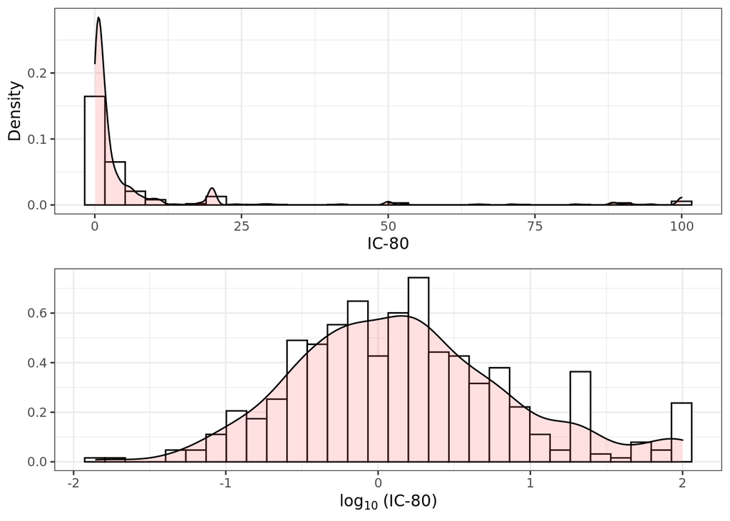

Figure 3.1: Histogram of IC-80 for the selected neutralizing antibody. Top row = original scale; bottom row = log10 scale (n = 476 observations with complete sequence data).

## 3.2 Super learner results

The weights assigned to each algorithm for Super Learner predicting IC-80 are shown in Table 3.1.

Table 3.1: Table of super learner weights for IC-80 (n = 476 observations with complete sequence data).

| Learner | Weight |
| --- | --- |
| SL.ranger.small | 0.00 |
| SL.ranger.reg | 0.49 |
| SL.ranger.large | 0.00 |
| SL.xgboost.2 | 0.31 |
| SL.xgboost.4 | 0.04 |
| SL.xgboost.6 | 0.00 |
| SL.xgboost.8 | 0.00 |
| SL.glmnet.0 | 0.00 |
| SL.glmnet.25 | 0.00 |
| SL.glmnet.50 | 0.16 |
| SL.glmnet.75 | 0.00 |
| SL.mean | 0.00 |

## 3.3 Predictive performance

The cross-validated performance, as measured by $R^2$, of the super learner and constituent algorithms (descriptions of algorithms shown in Table 1.1 in predicting IC-80 are shown in Figure 3.2.

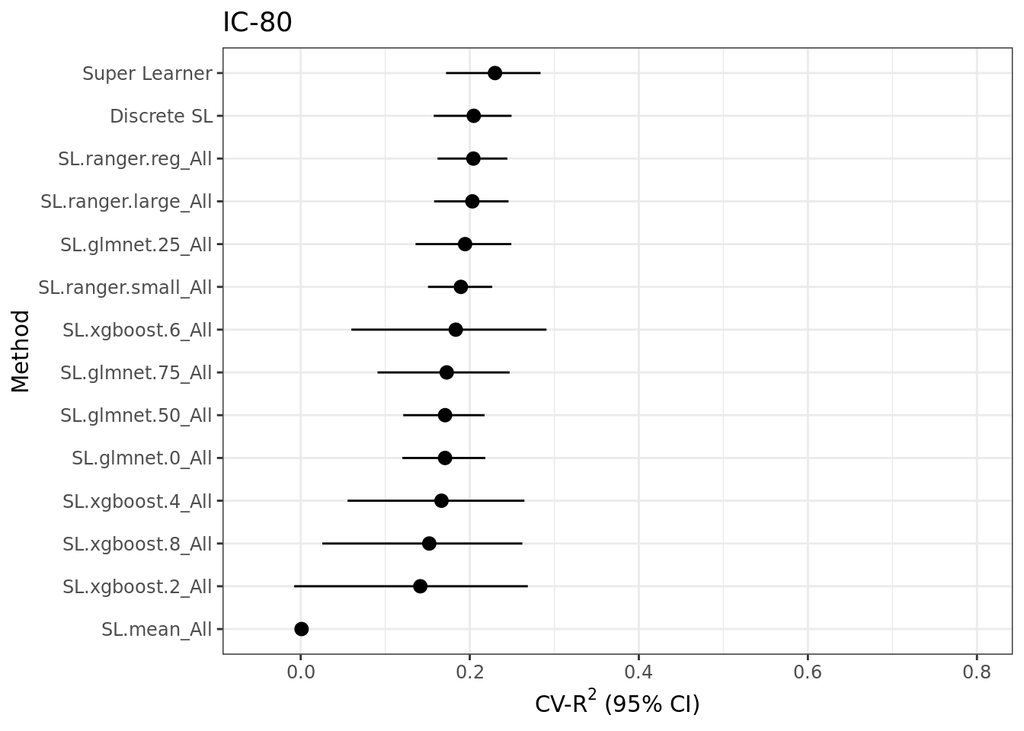

Figure 3.2: Cross-validated $R^2$ for estimated IC-80 (476 observations with complete sequence data)

Figure 3.3 shows cross-validated predictions of IC-80 plotted against observed values of IC-80, colored by cross-validation fold.

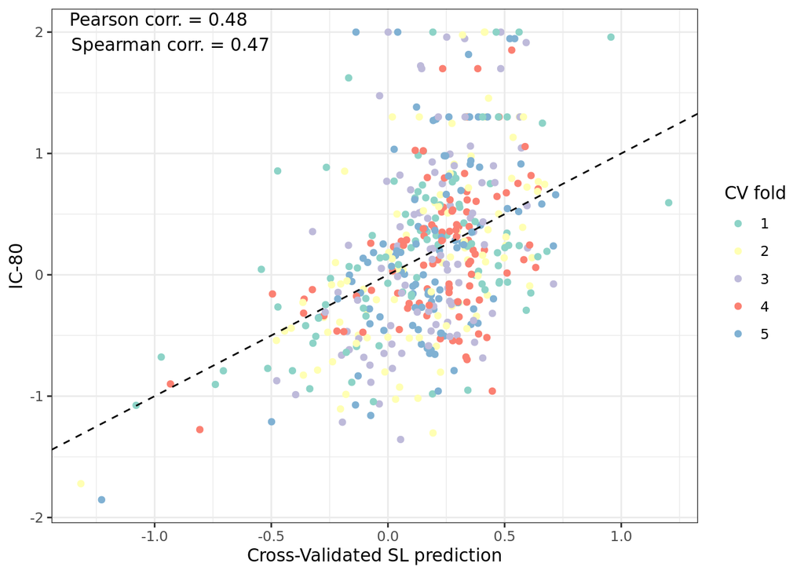

Figure 3.3: Cross-validated super learner predicted IC-80 plotted against actual IC-80 values (476 observations with complete sequence data) . Colors correspond to cross-validation folds.

## 3.4 Variable importance

### 3.4.1 Biological importance

We show the biological variable importance of groups of features (defined in Table 7.1) in predicting IC-80 in Figure 3.4. Importance is defined using the difference in $R^2$ values. The plot shows the marginal biological importance of the group relative to the null model with geographic confounders only. 95% confidence intervals and stars denoting p-values less than 0.05 are displayed in blue.

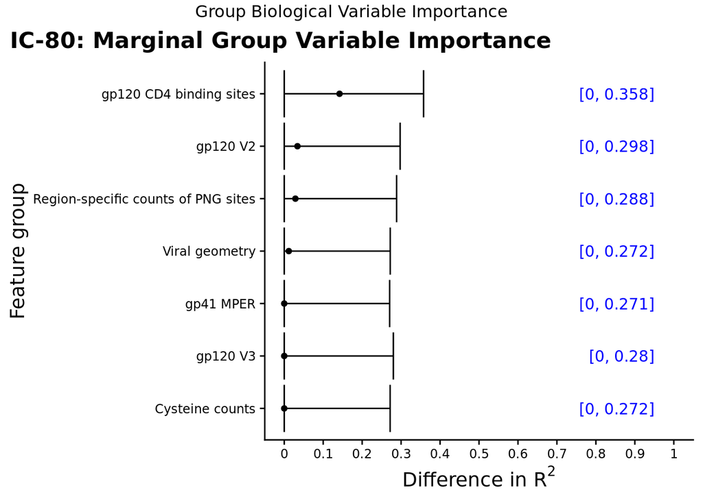

Figure 3.4: Group biological variable importance for predicting IC-80. We used the 476 observations with complete sequence data in this analysis. To estimate the prediction function based on geographic confounders only, we used 239 observations. To estimate the prediction function based on the feature group of interest plus geographic confounders, we used the remaining 237 observations.

We show the biological variable importance of individual features in predicting IC-80 in Figure 3.5. Importance is defined using the difference in $R^2$ values. The plot shows the marginal biological importance of the feature relative to the null model with geographic confounders only. 95% confidence intervals and stars denoting p-values less than 0.05 are displayed in blue.

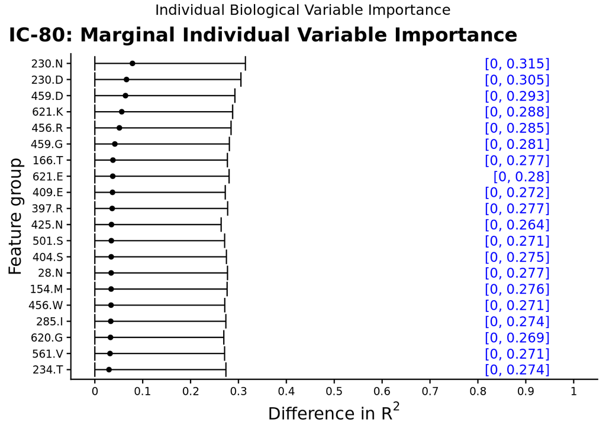

Figure 3.5: Individual biological variable importance for predicting IC-80. We used the 476 observations with complete sequence data in this analysis. To estimate the prediction function based on geographic confounders only, we used 239 observations. To estimate the prediction function based on the feature of interest plus geographic confounders, we used the remaining 237 observations.

### 3.4.2 Predictive importance

Table 3.2 shows the top 20 features. Specifically, the algorithm with the largest weight in the super learner ensemble was selected and associated variable importance metrics for this algorithm are shown. In this case, the highest weight was assigned to a rf algorithm, and thus the variable importance measures presented correspond to random forest variable permutation-based variable importance measures were computed and are shown by their rank. The permutation-based importance measures the decrease in predictive accuracy when making out-of-bag predictions and randomly permuting a given feature from its original values.

Table 3.2: The top 20 important features for predicting IC-80 as measured by their algorithm-specific importance.

| Feature | Importance |
| --- | --- |
| num.sequons.env | 1.4770718 |
| num.sequons.gp120 | 1.2590091 |
| length.gp120 | 1.1671033 |
| length.env | 1.0949137 |
| hxb2.236.T.1mer | 0.8670544 |
| hxb2.234.sequon_actual.1mer | 0.6198950 |
| length.v2 | 0.6009952 |
| hxb2.456.R.1mer | 0.5980996 |
| hxb2.429.R.1mer | 0.5828087 |
| hxb2.364.H.1mer | 0.5815565 |
| hxb2.268.E.1mer | 0.5383154 |
| hxb2.455.E.1mer | 0.5337705 |
| hxb2.238.P.1mer | 0.5262774 |
| hxb2.174.A.1mer | 0.5231975 |
| hxb2.640.Q.1mer | 0.5086771 |
| hxb2.459.G.1mer | 0.4826624 |
| hxb2.135.gap.1mer | 0.4783515 |
| hxb2.460.sequon_actual.1mer | 0.4626031 |
| hxb2.106.T.1mer | 0.4432797 |
| hxb2.620.G.1mer | 0.4361043 |

# 4 Results for IIP

## 4.1 Descriptive statistics

A summary of the distribution of IIP for the selected neutralizing antibody is shown in Figure 4.1.

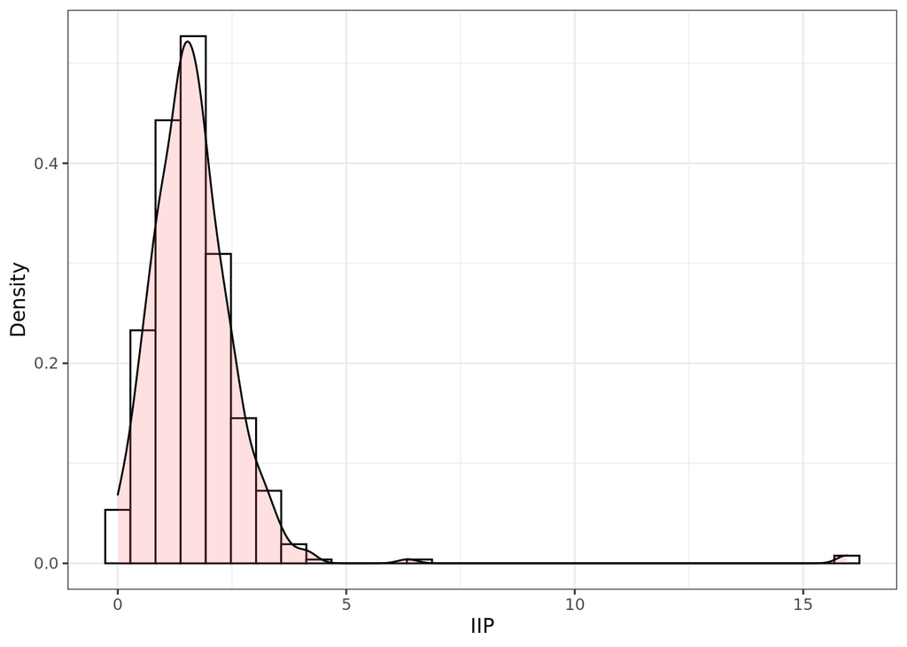

Figure 4.1: Histogram of IIP for the selected neutralizing antibody (n = 476 observations with complete sequence data).

## 4.2 Super learner results

The weights assigned to each algorithm for Super Learner predicting IIP are shown in Table 4.1.

Table 4.1: Table of super learner weights for IIP (n = 476 observations with complete sequence data).

| Learner | Weight |
| --- | --- |
| SL.ranger.small | 0.04 |
| SL.ranger.reg | 0.41 |
| SL.ranger.large | 0.00 |
| SL.xgboost.2 | 0.00 |
| SL.xgboost.4 | 0.00 |
| SL.xgboost.6 | 0.21 |
| SL.xgboost.8 | 0.00 |
| SL.glmnet.0 | 0.26 |
| SL.glmnet.25 | 0.00 |
| SL.glmnet.50 | 0.05 |
| SL.glmnet.75 | 0.00 |
| SL.mean | 0.02 |

## 4.3 Predictive performance

The cross-validated performance, as measured by $R^2$, of the super learner and constituent algorithms (descriptions of algorithms shown in Table 1.1 in predicting IIP are shown in Figure 4.2.

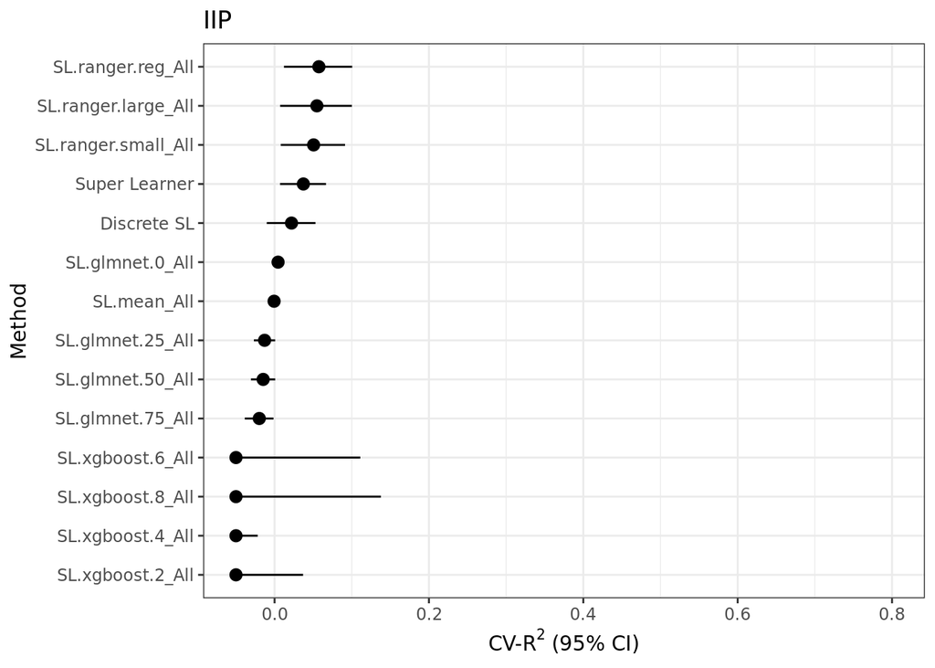

Figure 4.2: Cross-validated $R^2$ for estimated IIP (476 observations with complete sequence data)

Figure 4.3 shows cross-validated predictions of IIP plotted against observed values of IIP, colored by cross-validation fold.

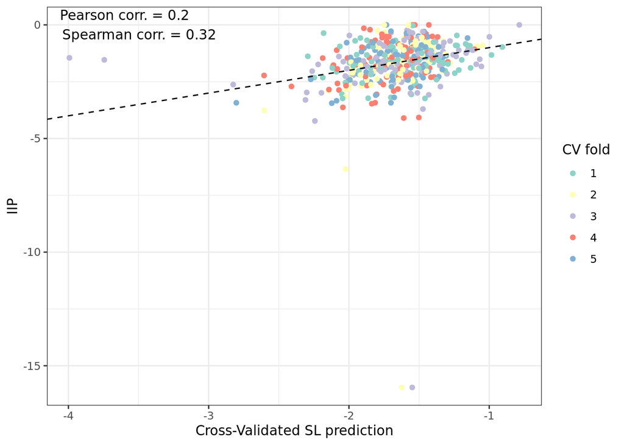

Figure 4.3: Cross-validated super learner predicted IIP plotted against actual IIP values (476 observations with complete sequence data) . Colors correspond to cross-validation folds.

## 4.4 Variable importance

### 4.4.1 Biological importance

We show the biological variable importance of groups of features (defined in Table 7.1) in predicting IIP in Figure 4.4. Importance is defined using the difference in $R^2$ values. The plot shows the marginal biological importance of the group relative to the null model with geographic confounders only. 95% confidence intervals and stars denoting p-values less than 0.05 are displayed in blue.

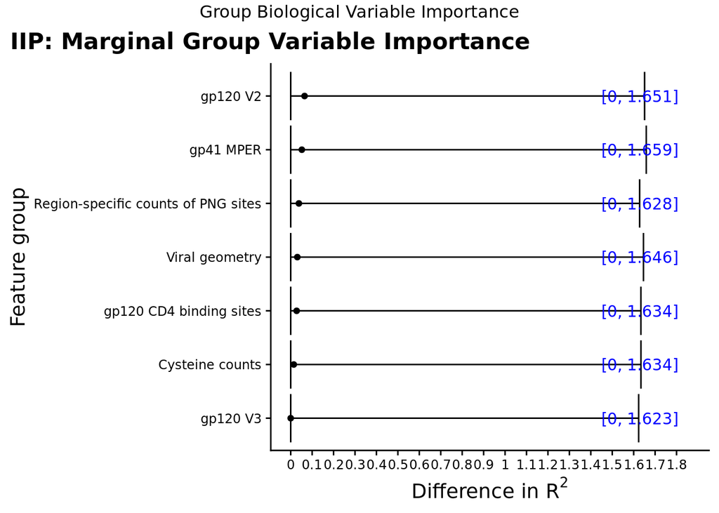

Figure 4.4: Group biological variable importance for predicting IIP. We used the 476 observations with complete sequence data in this analysis. To estimate the prediction function based on geographic confounders only, we used 239 observations. To estimate the prediction function based on the feature group of interest plus geographic confounders, we used the remaining 237 observations.

We show the biological variable importance of individual features in predicting IIP in Figure 4.5. Importance is defined using the difference in $R^2$ values. The plot shows the marginal biological importance of the feature relative to the null model with geographic confounders only. 95% confidence intervals and stars denoting p-values less than 0.05 are displayed in blue.

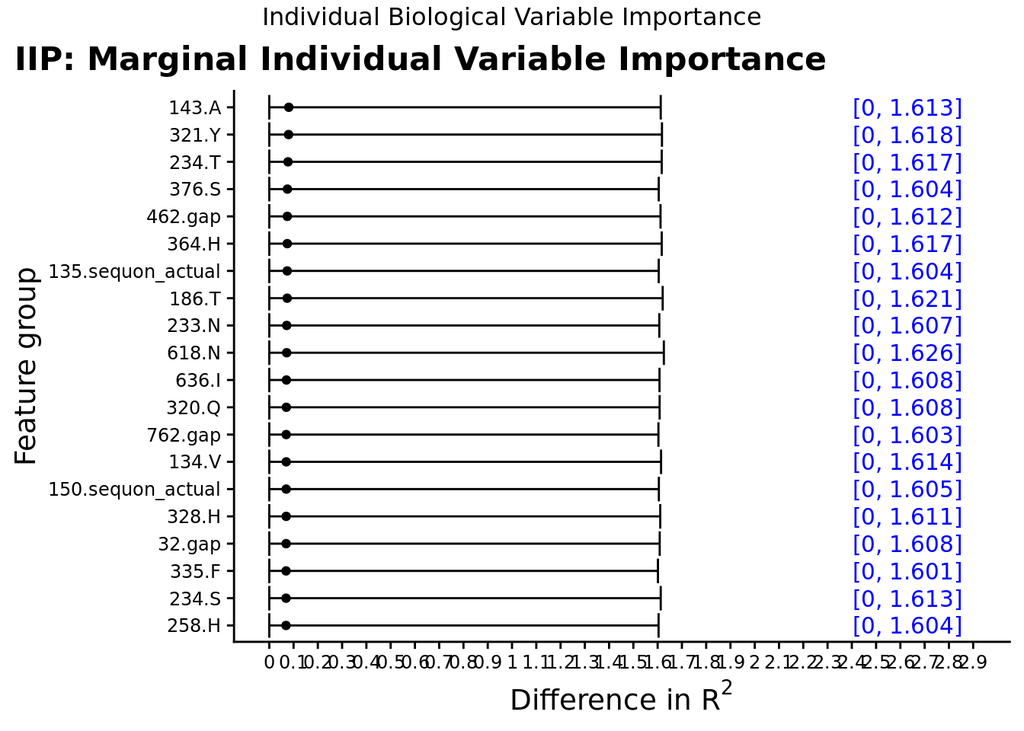

Figure 4.5: Individual biological variable importance for predicting IIP. We used the 476 observations with complete sequence data in this analysis. To estimate the prediction function based on geographic confounders only, we used 239 observations. To estimate the prediction function based on the feature of interest plus geographic confounders, we used the remaining 237 observations.

### 4.4.2 Predictive importance

Table 4.2 shows the top 20 features. Specifically, the algorithm with the largest weight in the super learner ensemble was selected and associated variable importance metrics for this algorithm are shown. In this case, the highest weight was assigned to a rf algorithm, and thus the variable importance measures presented correspond to random forest variable permutation-based variable importance measures were computed and are shown by their rank. The permutation-based importance measures the decrease in predictive accuracy when making out-of-bag predictions and randomly permuting a given feature from its original values.

Table 4.2: The top 20 important features for predicting IIP as measured by their algorithm-specific importance.

| Feature | Importance |
| --- | --- |
| hxb2.466.G.1mer | 13.073877 |
| hxb2.560.K.1mer | 7.698151 |
| hxb2.395.K.1mer | 6.617514 |
| hxb2.340.S.1mer | 5.606672 |
| hxb2.412.V.1mer | 5.504944 |
| hxb2.379.N.1mer | 5.401316 |
| hxb2.399.E.1mer | 5.309577 |
| hxb2.405.W.1mer | 4.828094 |
| hxb2.504.K.1mer | 4.706665 |
| hxb2.842.Y.1mer | 4.638783 |
| hxb2.319.S.1mer | 4.564451 |
| hxb2.777.T.1mer | 4.343343 |
| hxb2.144.Q.1mer | 4.251881 |
| hxb2.533.A.1mer | 3.832801 |
| hxb2.408.Y.1mer | 3.707382 |
| hxb2.343.I.1mer | 3.682244 |
| hxb2.295.K.1mer | 3.643376 |
| hxb2.400.S.1mer | 3.629963 |
| hxb2.456.R.1mer | 3.580979 |
| hxb2.783.T.1mer | 3.364940 |

# 5 Results for estimated sensitivity

## 5.1 Descriptive statistics

Out of the 476 sequences, 111 were estimated to be resistant to the antibody, while 365 were estimated to be sensitive.

## 5.2 Super learner results

The weights assigned to each algorithm for Super Learner predicting estimated sensitivity are shown in Table 5.1.

Table 5.1: Table of super learner weights for estimated sensitivity (n = 476 observations with complete sequence data).

| Learner | Weight |
| --- | --- |
| SL.ranger.small | 0.80 |
| SL.ranger.reg | 0.00 |
| SL.ranger.large | 0.14 |
| SL.xgboost.2 | 0.00 |
| SL.xgboost.4 | 0.00 |
| SL.xgboost.6 | 0.06 |
| SL.xgboost.8 | 0.00 |
| SL.glmnet.0 | 0.00 |
| SL.glmnet.25 | 0.00 |
| SL.glmnet.50 | 0.00 |
| SL.glmnet.75 | 0.00 |
| SL.mean | 0.00 |

## 5.3 Predictive performance

The cross-validated performance of super learner, as measured by area under the ROC curve, in predicting estimated sensitivity relative to other candidate algorithms is shown in Figure 5.1. Figure 5.2 shows cross-validated ROC curves for this endpoint.

The cross-validated performance of the learner with tuning parameters selected via cross-validation, as measured by area under the ROC curve, and learners with each individual value of tuning parameters are shown in Figure 5.2.

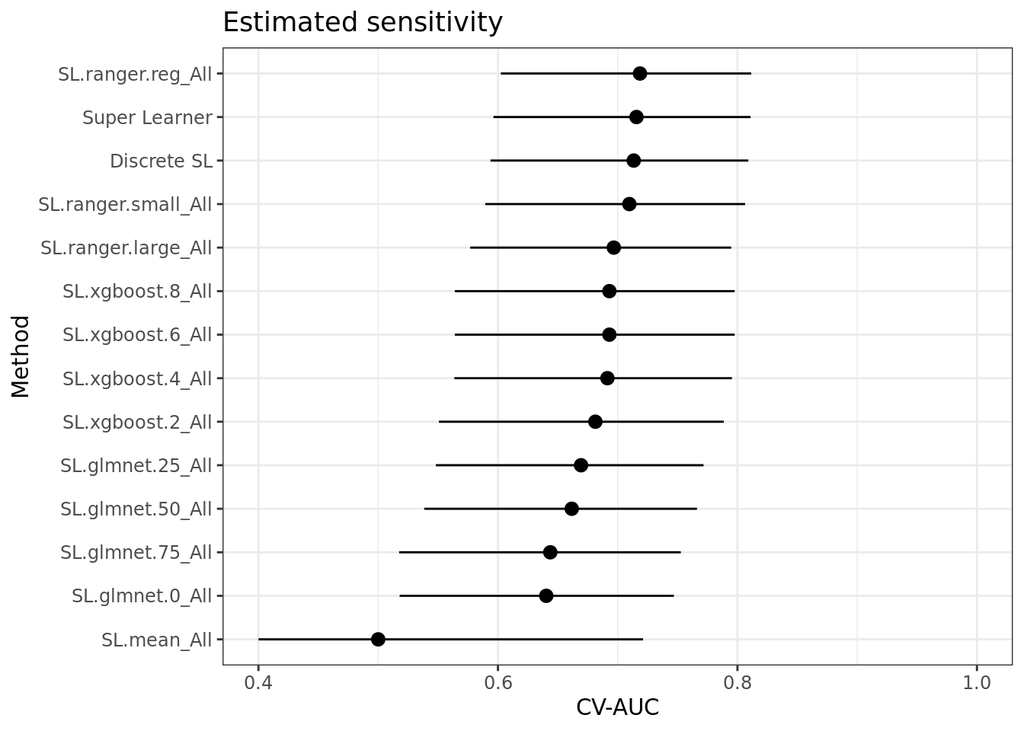

Figure 5.1: Cross-validated AUC for predicting sensitivity based on estimated sensitivity (n = 476 observations with complete sequence data).

Figure 5.2 shows the cross-validated ROC curve for predicting estimated sensitivity.

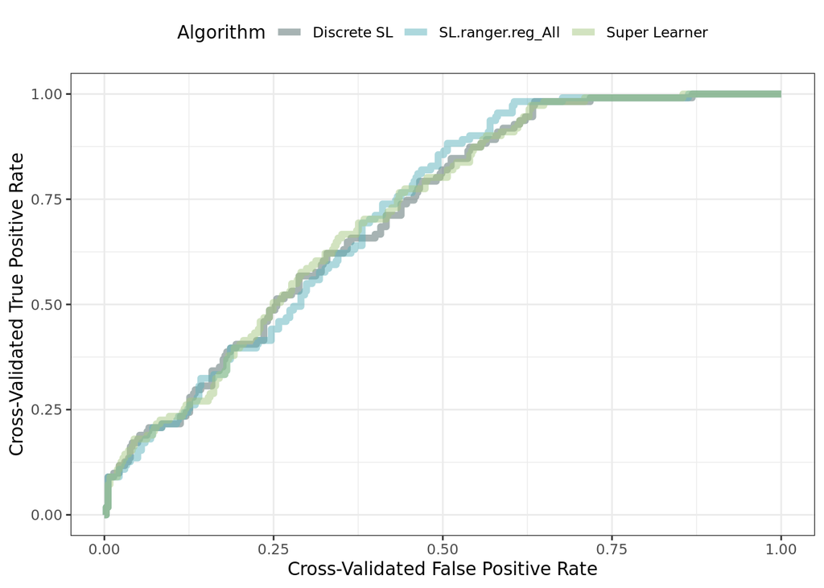

Figure 5.2: Cross-validated ROC curve for the super learner, discrete super learner, and single best performing algorithm for predicting estimated sensitivity (n = 476 observations with complete sequence data).

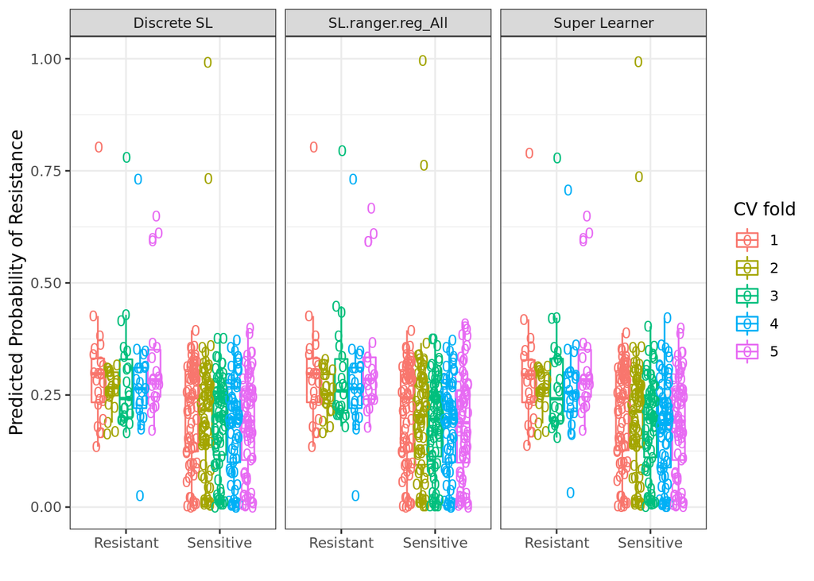

Figure 5.3: Cross-validated predicted probabilities of estimated resistance made by super learner, discrete super learner, and single best performing algorithm colored by cross-validation fold (n = 476 observations with complete sequence data).

## 5.4 Variable importance

### 5.4.1 Biological importance

We show the biological variable importance of groups of features (defined in Table 7.1) in predicting estimated sensitivity in Figure 5.4. Importance is defined using the difference in AUCs. The plot shows the marginal biological importance of the group relative to the null model with geographic confounders only. 95% confidence intervals and stars denoting p-values less than 0.05 are displayed in blue.

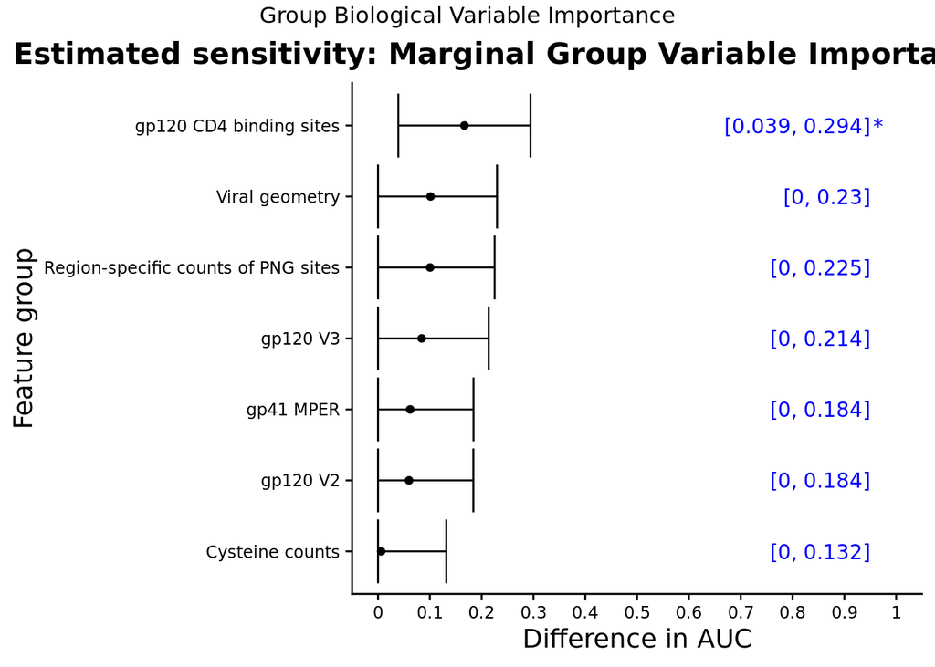

Figure 5.4: Group biological variable importance for predicting estimated sensitivity. We used the 476 observations with complete sequence data in this analysis. To estimate the prediction function based on geographic confounders only, we used 239 observations. To estimate the prediction function based on the feature group of interest plus geographic confounders, we used the remaining 237 observations.

We show the biological variable importance of individual features in predicting estimated sensitivity in Figure 5.5. Importance is defined using the difference in AUCs. The plot shows the marginal biological importance of the feature relative to the null model with geographic confounders only. 95% confidence intervals and stars denoting p-values less than 0.05 are displayed in blue.

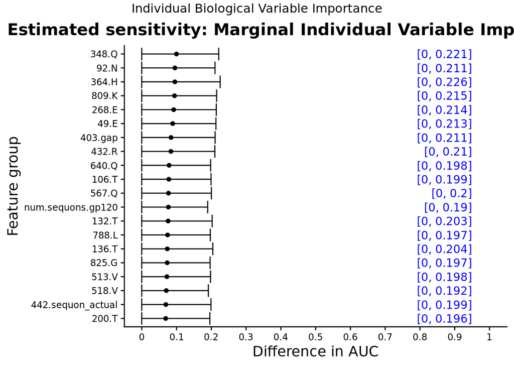

Figure 5.5: Individual biological variable importance for predicting estimated sensitivity. We used the 476 observations with complete sequence data in this analysis. To estimate the prediction function based on geographic confounders only, we used 239 observations. To estimate the prediction function based on the feature of interest plus geographic confounders, we used the remaining 237 observations.

### 5.4.2 Predictive importance

Table 5.2 shows the top 20 features. Specifically, the algorithm with the largest weight in the super learner ensemble was selected and associated variable importance metrics for this algorithm are shown. In this case, the highest weight was assigned to a rf algorithm, and thus the variable importance measures presented correspond to random forest variable permutation-based variable importance measures were computed and are shown by their rank. The permutation-based importance measures the decrease in predictive accuracy when making out-of-bag predictions and randomly permuting a given feature from its original values.

Table 5.2: The top 20 important features for predicting estimated sensitivity as measured by their algorithm-specific importance.

| Feature | Importance |
| --- | --- |
| num.sequons.env | 0.6100548 |
| num.sequons.gp120 | 0.5261357 |
| length.gp120 | 0.5012188 |
| length.env | 0.5005803 |
| hxb2.169.Q.1mer | 0.3718238 |
| length.v2 | 0.3495710 |
| hxb2.136.F.1mer | 0.3287356 |
| hxb2.193.M.1mer | 0.3266557 |
| hxb2.169.K.1mer | 0.3097409 |
| hxb2.460.sequon_actual.1mer | 0.2923982 |
| num.cysteine.env | 0.2858600 |
| hxb2.364.H.1mer | 0.2697535 |
| hxb2.513.V.1mer | 0.2529770 |
| hxb2.230.D.1mer | 0.2523992 |
| hxb2.148.I.1mer | 0.2507330 |
| hxb2.595.L.1mer | 0.2475729 |
| hxb2.856.I.1mer | 0.2433639 |
| hxb2.265.I.1mer | 0.2352087 |
| hxb2.193.L.1mer | 0.2291850 |
| hxb2.743.E.1mer | 0.2284992 |

# 6 Results for multiple sensitivity

## 6.1 Descriptive statistics

Out of the 476 sequences, 111 were estimated to be resistant to the antibody, while 365 were estimated to be sensitive.

## 6.2 Super learner results

The weights assigned to each algorithm for Super Learner predicting multiple sensitivity are shown in Table 6.1.

Table 6.1: Table of super learner weights for multiple sensitivity (n = 476 observations with complete sequence data).

| Learner | Weight |
| --- | --- |
| SL.ranger.small | 0.00 |
| SL.ranger.reg | 0.00 |
| SL.ranger.large | 0.92 |
| SL.xgboost.2 | 0.00 |
| SL.xgboost.4 | 0.00 |
| SL.xgboost.6 | 0.08 |
| SL.xgboost.8 | 0.00 |
| SL.glmnet.0 | 0.00 |
| SL.glmnet.25 | 0.00 |
| SL.glmnet.50 | 0.00 |
| SL.glmnet.75 | 0.00 |
| SL.mean | 0.00 |

## 6.3 Predictive performance

The cross-validated performance of super learner, as measured by area under the ROC curve, in predicting multiple sensitivity relative to other candidate algorithms is shown in Figure 6.1. Figure 6.2 shows cross-validated ROC curves for this endpoint.

The cross-validated performance of the learner with tuning parameters selected via cross-validation, as measured by area under the ROC curve, and learners with each individual value of tuning parameters are shown in Figure 6.2.

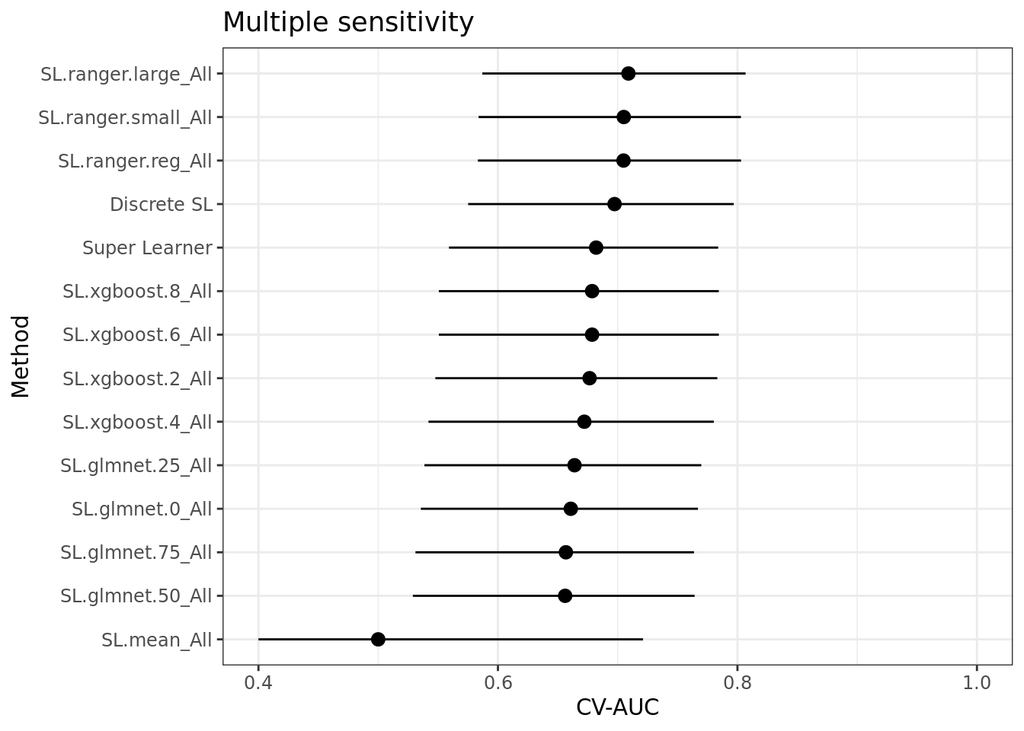

Figure 6.1: Cross-validated AUC for multiple sensitivity (n = 476 observations with complete sequence data).

Figure 6.2 shows the cross-validated ROC curve for predicting multiple sensitivity.

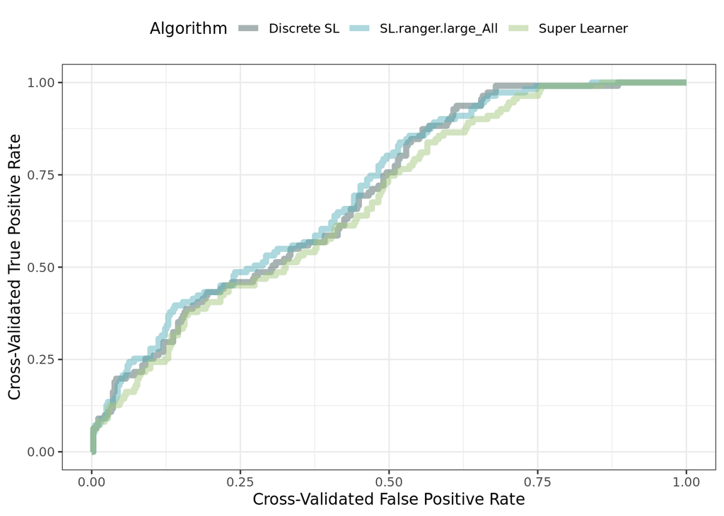

Figure 6.2: Cross-validated ROC curve for the super learner, discrete super learner, and single best performing algorithm for predicting multiple sensitivity (n = 476 observations with complete sequence data).

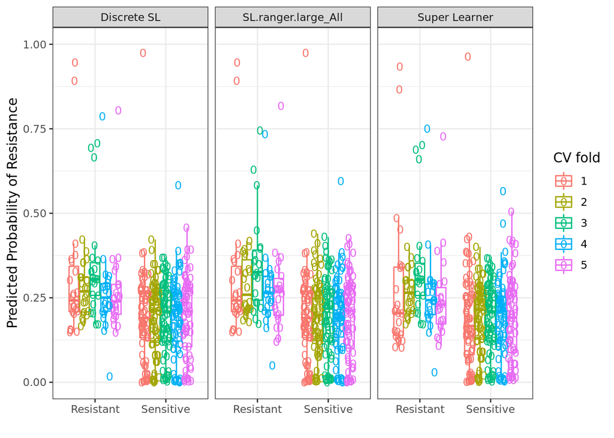

Figure 6.3: Cross-validated predicted probabilities of multiple resistance made by super learner, discrete super learner, and single best performing algorithm colored by cross-validation fold (n = 476 observations with complete sequence data).

## 6.4 Variable importance

### 6.4.1 Biological importance

We show the biological variable importance of groups of features (defined in Table 7.1) in predicting multiple sensitivity in Figure 6.4. Importance is defined using the difference in AUCs. The plot shows the marginal biological importance of the group relative to the null model with geographic confounders only. 95% confidence intervals and stars denoting p-values less than 0.05 are displayed in blue.

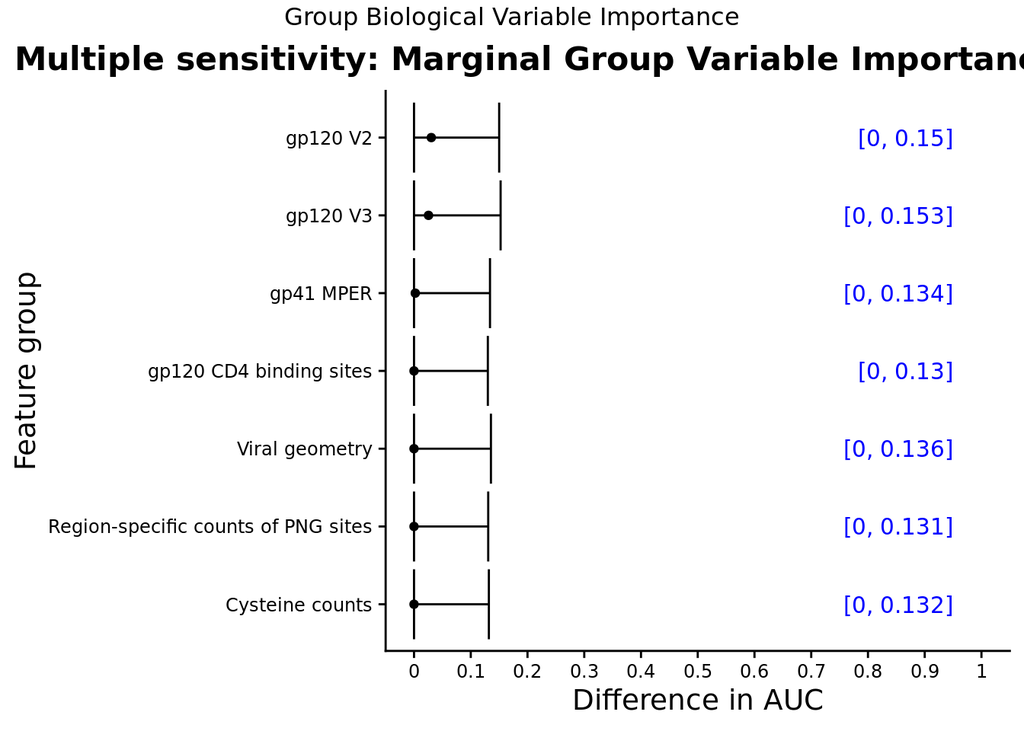

Figure 6.4: Group biological variable importance for predicting multiple sensitivity. We used the 476 observations with complete sequence data in this analysis. To estimate the prediction function based on geographic confounders only, we used 239 observations. To estimate the prediction function based on the feature group of interest plus geographic confounders, we used the remaining 237 observations.

We show the biological variable importance of individual features in predicting multiple sensitivity in Figure 6.5. Importance is defined using the difference in AUCs. The plot shows the marginal biological importance of the feature relative to the null model with geographic confounders only. 95% confidence intervals and stars denoting p-values less than 0.05 are displayed in blue.

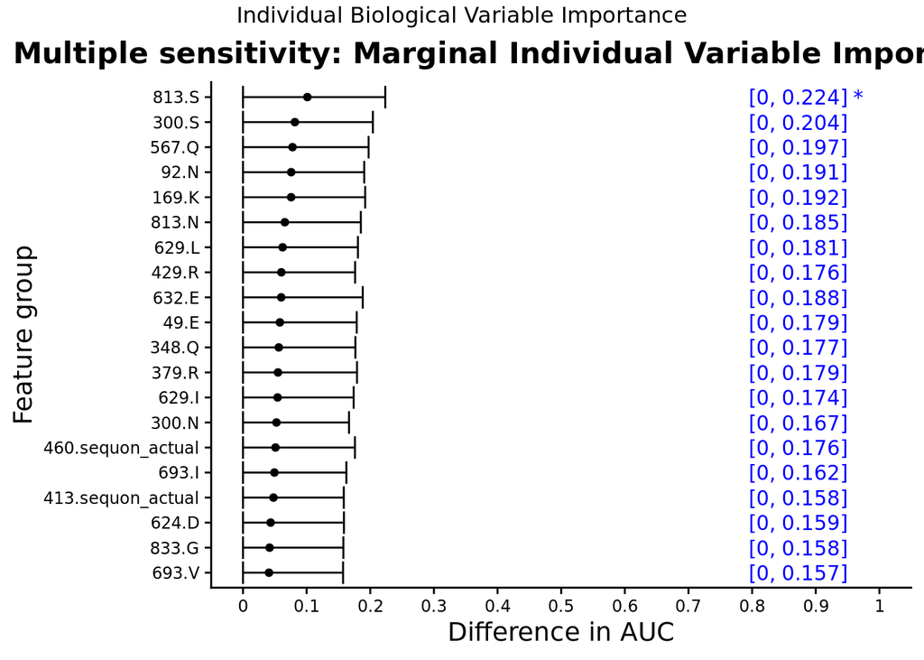

Figure 6.5: Individual biological variable importance for predicting multiple sensitivity. We used the 476 observations with complete sequence data in this analysis. To estimate the prediction function based on geographic confounders only, we used 239 observations. To estimate the prediction function based on the feature of interest plus geographic confounders, we used the remaining 237 observations.

### 6.4.2 Predictive importance

Table 6.2 shows the top 20 features. Specifically, the algorithm with the largest weight in the super learner ensemble was selected and associated variable importance metrics for this algorithm are shown. In this case, the highest weight was assigned to a rf algorithm, and thus the variable importance measures presented correspond to random forest variable permutation-based variable importance measures were computed and are shown by their rank. The permutation-based importance measures the decrease in predictive accuracy when making out-of-bag predictions and randomly permuting a given feature from its original values.

Table 6.2: The top 20 important features for predicting multiple sensitivity as measured by their algorithm-specific importance.

| Feature | Importance |
| --- | --- |
| num.sequons.gp120 | 0.9980934 |
| num.sequons.env | 0.8599998 |
| hxb2.136.F.1mer | 0.8282063 |
| hxb2.169.Q.1mer | 0.7900180 |
| length.gp120 | 0.6239219 |
| length.env | 0.5904083 |
| hxb2.364.H.1mer | 0.5736369 |
| hxb2.460.sequon_actual.1mer | 0.5550167 |
| hxb2.193.M.1mer | 0.5024819 |
| hxb2.148.I.1mer | 0.4718318 |
| hxb2.364.T.1mer | 0.4663840 |
| hxb2.185.G.1mer | 0.4595195 |
| length.v2 | 0.4332205 |
| hxb2.154.M.1mer | 0.4323798 |
| hxb2.344.S.1mer | 0.4116833 |
| hxb2.160.S.1mer | 0.4041565 |
| hxb2.513.V.1mer | 0.3953288 |
| hxb2.138.A.1mer | 0.3794705 |
| hxb2.193.L.1mer | 0.3685398 |
| hxb2.429.G.1mer | 0.3589970 |

# 7 Variable group definitions

Table 7.1 provides the individual HXB2 coordinates and variable names of the variables that make up each of the variable groups considered for importance.

Table 7.1: Individual variables within each variable group.

|  | Variables |
| --- | --- |
| gp120_cd4bs | 61.F, 61.H, 61.I, 61.L, 61.Q, 61.T, 61.V, 61.Y, 62.A, 62.D, 62.E, 62.G, 62.H, 62.I, 62.K, 62.M, 62.N, 62.R, 62.S, 62.T, 62.V, 62.Y, 66.H, 66.R, 120.I, 120.T, 120.V, 124.F, 124.H, 124.I, 124.P, 124.Y, … |
| gp120_v2 | 121.E, 121.K, 121.M, 121.Q, 121.R, 123.A, 123.T, 124.F, 124.H, 124.I, 124.P, 124.Y, 127.I, 127.V, 157.C, 157.D, 157.I, 157.K, 157.X, 157.gap, 158.D, 158.E, 158.S, 158.T, 158.gap, 159.D, 159.F, 159.L, … |
| gp120_v3 | 296.C, 296.R, 297.A, 297.E, 297.I, 297.K, 297.L, 297.M, 297.N, 297.Q, 297.R, 297.S, 297.T, 297.V, 298.G, 298.R, 299.E, 299.F, 299.H, 299.L, 299.N, 299.P, 299.T, 299.V, 300.A, 300.C, 300.D, 300.F, 300.… |
| gp41_mper | 609.A, 609.F, 609.H, 609.K, 609.L, 609.P, 609.Q, 609.R, 609.S, 609.Y, 657.E, 657.K, 657.V, 658.E, 658.H, 658.K, 658.L, 658.N, 658.Q, 658.R, 659.A, 659.D, 659.E, 659.K, 659.N, 659.R, 659.S, 661.F, 661.… |
| glyco | num.sequons.env, num.sequons.gp120, num.sequons.v2, num.sequons.v3, num.sequons.v5 |
| cysteines | num.cysteine.env, num.cysteine.gp120, num.cysteine.v2, num.cysteine.v3, num.cysteine.v5 |
| geometry | length.env, length.gp120, length.v2, length.v3, length.v5 |